# Lab 4 Empirical Spatial Mean, Temporal Means, Covariances and EOFs

## 4.1 Empirical Spatial Means

The empirical spatial mean is a spatial quantity that can be stored in a new data frame that contains the spatial locations and the respective average maximum temperature at each location.

To keep the data size manageable, we take a subset of it corresponding to the maximum daily temperatures in the months May–September 1993.

```r
library("gstat")
library("sp")
library("spacetime")
library("STRbook")
library("tidyverse")

data("NOAA_df_1990", package = "STRbook")
Tmax <- filter(NOAA_df_1990, # subset the data
               proc == "Tmax" & # only max temperature
                 month %in% 5:9 & # May to September
                 year == 1993) # year of 1993
Tmax$t <- Tmax$julian - 728049 # create a new time variable
```

We group by longitude and latitude, and then we compute the average maximum temperature at each of the separate longitude–latitude coordinates.

```r
spat_av <- group_by(Tmax, lat, lon) %>% # group by lon-lat
summarise(mu_emp = mean(z)) # mean for each lon-lat
```

We can now plot the average maximum temperature per station and see how this varies according to longitude and latitude.

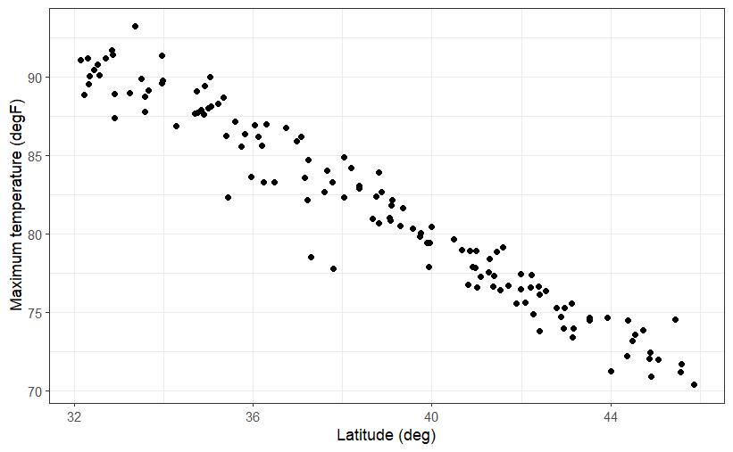

```r
lat_means <- ggplot(spat_av) +
  geom_point(aes(lat, mu_emp)) +
  xlab("Latitude (deg)") +
  ylab("Maximum temperature (degF)") + theme_bw()

lon_means <- ggplot(spat_av) +
  geom_point(aes(lon, mu_emp)) +
  xlab("Longitude (deg)") +
  ylab("Maximum temperature (degF)") + theme_bw()

lat_means
```

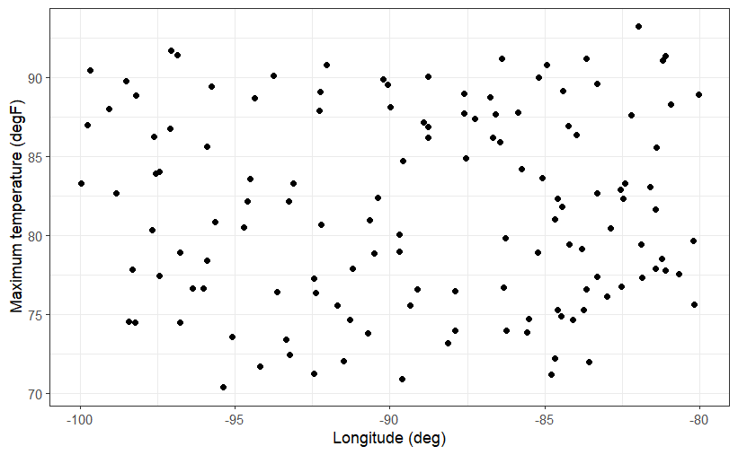

```r
lon_means
```

## 4.2 Empirical Temporal Means

The empirical temporal mean can be computed by grouping the data by time and summarizing using the `summarise` function.

```r
Tmax_av <- group_by(Tmax, date) %>%
summarise(meanTmax = mean(z))
```

The variable Tmax_av is a data frame containing the average maximum temperature on each day (averaged across all the stations). This can be visualized easily, together with the original raw data, using ggplot2.

```r
gTmaxav <-
  ggplot() +
  geom_line(data = Tmax,aes(x = date, y = z, group = id),
            colour = "blue", alpha = 0.04) +
  geom_line(data = Tmax_av, aes(x = date, y = meanTmax)) +
  xlab("Month") + ylab("Maximum temperature (degF)") +
  theme_bw()
```

## 4.3 Empirical Covariances

The most straightforward way to compute the empirical covariance matrix is using the `cov` function in R.

```r
X <- select(Tmax, lon, lat, t, z) %>% # select columns
  spread(t, z) %>% # make time-wide
  select(-lon, -lat) %>% # drop coord info
  t() # make space-wide

Lag0_cov <- cov(X, use = 'complete.obs')
Lag1_cov <- cov(X[-1, ], X[-nrow(X),], use = 'complete.obs')
```

In practice, it is very hard to gain any intuition from these matrices, since points in a two-dimensional space do not have any specific ordering. We split the domain into either latitudinal or longitudinal strips, and then plot the spatial covariance matrix associated with each strip. In the following, we split the domain into **four** longitudinal strips (similar code can be used to generate latitudinal strips).

```r
spat_df <- filter(Tmax, t == 1) %>% # lon/lat coords of stations
  select(lon, lat) %>% # select lon/lat only
  arrange(lon, lat) # sort ascending by lon/lat
m <- nrow(spat_av) # number of stations


spat_df$n <- 1:nrow(spat_df) # assign an index to each station
lim_lon <- range(spat_df$lon) # range of lon coordinates
lon_strips <- seq(lim_lon[1], # create 4 long. strip boundaries
                  lim_lon[2],
                  length = 5)
spat_df$lon_strip <- cut(spat_df$lon, # bin the lon into
                         lon_strips, # their respective bins
                         labels = FALSE, # don't assign labels
                         include.lowest = TRUE) # include edges
```

`STRbook` provides a function `plot_cov_strips` that takes an empirical covariance matrix `C` and a data frame in the same format as `spat_df`, and then plots the covariance matrix associated with each longitudinal strip.

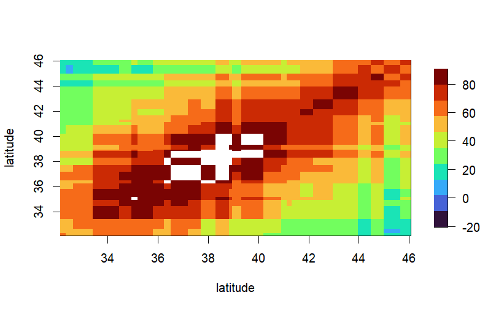

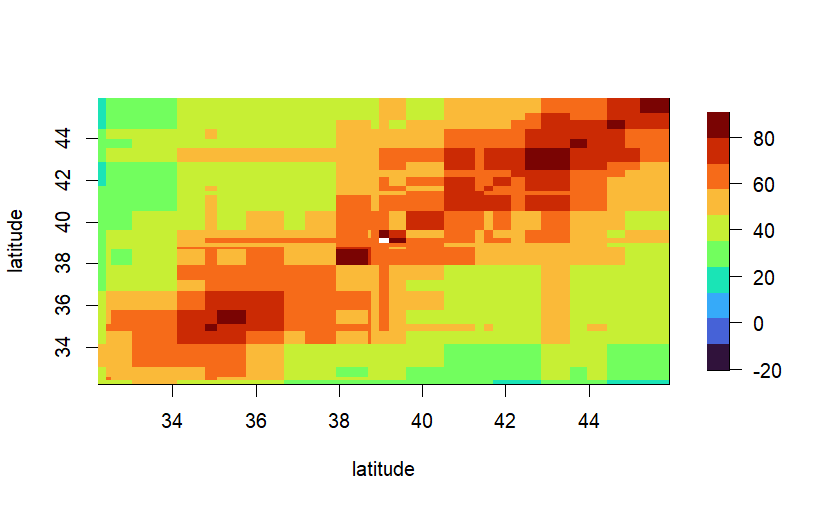

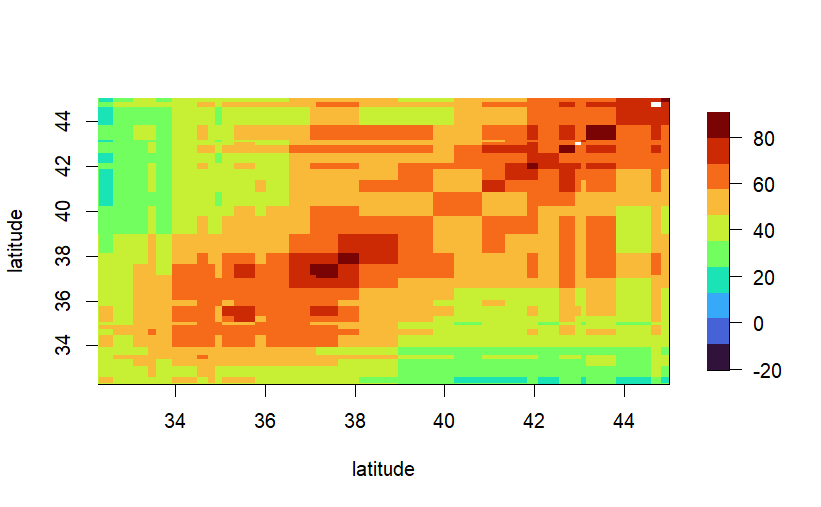

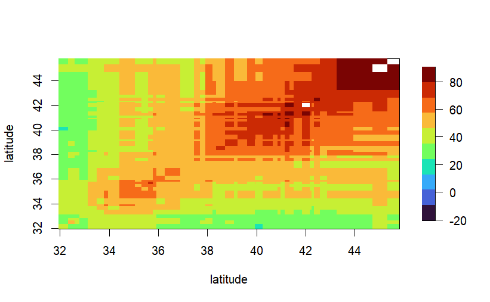

```r
plot_cov_strips(Lag0_cov, spat_df) # plot the lag-0 matrices
```

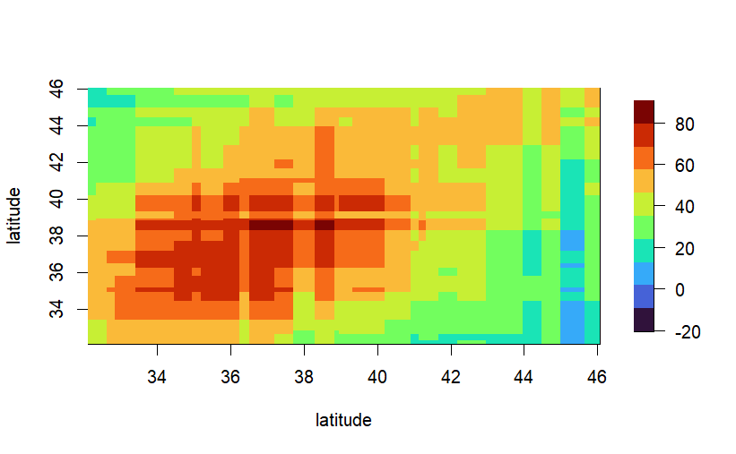

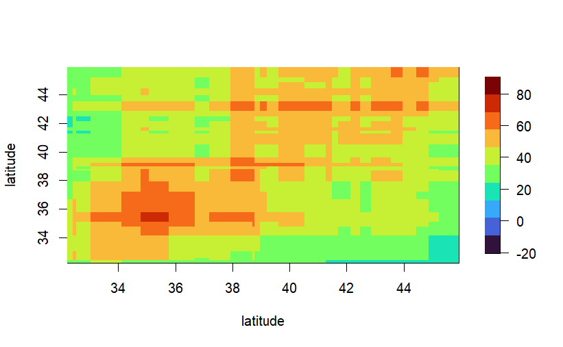

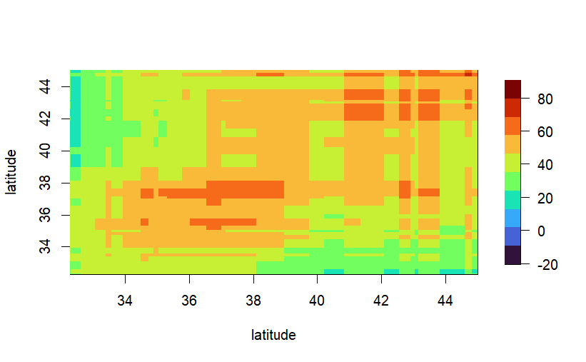

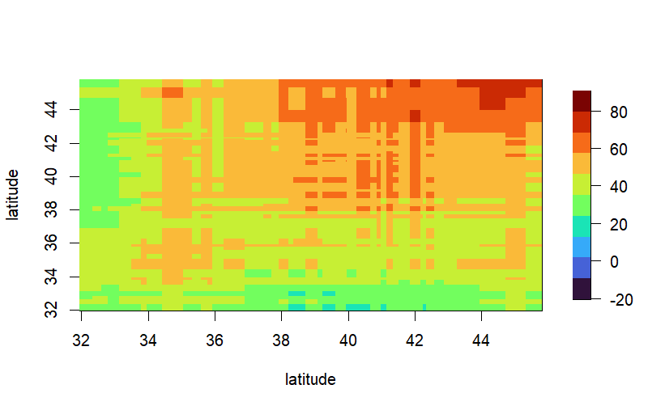

```r
plot_cov_strips(Lag1_cov, spat_df) # plot the lag-1 matrices
```

## 4.4 Empirical Orthogonal Functions (EOFs)

First we load the lon-lat coordinates of the SST grid, and the SST data set itself which is in time-wide format.

```r
data("SSTlonlat", package = "STRbook")
data("SSTdata", package = "STRbook")
```

Prior to carrying out an SVD, we need to put the data set into spacewide format, mean-correct it, and then standardize it.

```r
## Put data into space-wide form
Z <- t(SSTdata)
dim(Z)
```

```
[1]  399 2520
```

```r
## First find the matrix we need to subtract:
spat_mean <- apply(SSTdata, 1, mean)
nT <- ncol(SSTdata)
## Then subtract and standardize:
Zspat_detrend <- Z - outer(rep(1, nT), spat_mean)
Zt <- 1/sqrt(nT - 1)*Zspat_detrend
```

Finally, to carry out the SVD we run

```r
E <- svd(Zt)
```

The SVD returns a list `E` containing the matrices $V$, $U$, and the singular values $diag(D)$. The matrix $V$ contains the EOFs in space-wide format. We change the column names of this matrix, and append the lon-lat coordinates to it as follows.

```r
V <- E$v
colnames(E$v) <- paste0("EOF", 1:ncol(SSTdata)) # label columns
EOFs <- cbind(SSTlonlat, E$v)
head(EOFs[, 1:6])
```

|  | lon | lat | EOF1 | EOF2 | EOF3 | EOF4 |
| --- | --- | --- | --- | --- | --- | --- |
| 1 | 124 | -29 | -0.0004444571 | -0.0261718690 | 0.0122865093 | 0.006234095 |
| 2 | 126 | -29 | 0.0008341521 | -0.0167297065 | 0.0108957301 | 0.006570711 |
| 3 | 128 | -29 | 0.0027146345 | -0.0067808423 | 0.0094265177 | 0.006832442 |
| 4 | 130 | -29 | 0.0045180785 | 0.0042239506 | 0.0065630719 | 0.009233298 |
| 5 | 132 | -29 | 0.0043094937 | 0.0075929699 | 0.0011062015 | 0.015090959 |
| 6 | 134 | -29 | 0.0026456615 | 0.0001549839 | 0.0006939798 | 0.017340254 |

```r
TS <- data.frame(E$u) %>% # convert U to data frame
  mutate(t = 1:nrow(E$u)) %>% # add a time field
  gather(EOF, PC, -t) # put columns (except time)
                      # into long-table format with
                      # EOF-PC as key-value pair

TS$nPC <- TS$PC * sqrt(nT-1)
```

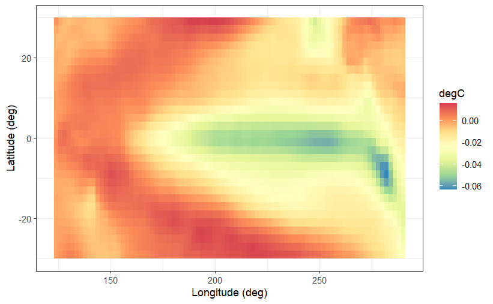

```r
ggplot(EOFs) + geom_tile(aes(x = lon, y = lat, fill = EOF1)) +
fill_scale(name = "degC") + theme_bw() +
xlab("Longitude (deg)") + ylab("Latitude (deg)")
```